# Practical machine Learning Project on Coursera

Charles

July 1, 2019

## Introduction

Using devices such as Jawbone Up, Nike FuelBand, and Fitbit it is now possible to collect a large amount of data about personal activity relatively inexpensively. These type of devices are part of the quantified self movement - a group of enthusiasts who take measurements about themselves regularly to improve their health, to find patterns in their behavior, or because they are tech geeks. One thing that people regularly do is quantify how much of a particular activity they do, but they rarely quantify how well they do it. In this project, your goal will be to use data from accelerometers on the belt, forearm, arm, and dumbell of 6 participants. They were asked to perform barbell lifts correctly and incorrectly in 5 different ways. More information is available from the website here: http://web.archive.org/web/20161224072740/http:/groupware.les.inf.puc-rio.br/har (see the section on the Weight Lifting Exercise Dataset).

## Data

- The training data for this project are available here:

https://d396qusza40orc.cloudfront.net/predmachlearn/pml-training.csv

- The test data are available here:

https://d396qusza40orc.cloudfront.net/predmachlearn/pml-testing.csv

The data for this project come from this source: http://groupware.les.inf.puc-rio.br/har. If you use the document you create for this class for any purpose please cite them as they have been very generous in allowing their data to be used for this kind of assignment.

## Getting the Data

```r
trainUrl <- "http://d396qusza40orc.cloudfront.net/predmachlearn/pml-training.csv"
testUrl <- "http://d396qusza40orc.cloudfront.net/predmachlearn/pml-testing.csv"
destfile2 <- "destfile.csv"
destfile3 <- "destfile.csv"
if(!file.exists(destfile2))
  {
  download.file(trainUrl,
                destfile = destfile2,
                method = "curl")
}
if(!file.exists(destfile3))
{
  download.file(testUrl1,
                destfile = destfile3,
                method = "curl")
}
training <- read.csv(url(trainUrl), na.strings=c("NA","#DIV/0!",""))
testing <- read.csv(url(testUrl), na.strings=c("NA","#DIV/0!",""))
```

```r
library(corrplot)
```

## Loading Required packages

```r
library(caret)
```

```r
library(rpart.plot)
library(RColorBrewer)
library(rattle)
library(randomForest)
library(corrplot)
library(e1071)
```

partitioning of data into training of 60% and test of 40%

```r
Train60 <- createDataPartition(y=training$classe, p=0.6, list=FALSE)
Training <- training[Train60, ]
Testing <- training[-Train60, ]
```

```r
dim(Training)
```

```
## [1] 11776   160
```

```r
dim(Testing)
```

```
## [1] 7846  160
```

*Removing Nas*

```r
AllNA    <- sapply(Training, function(x) mean(is.na(x))) > 0.95
Training <- Training[, AllNA==FALSE]
Testing  <- Testing[, AllNA==FALSE]



Training <- Training[, -c(1:7)]
Testing <- Testing[, -c(1:7)]
dim(Training)
```

```
## [1] 11776    53
```

```r
dim(Testing)
```

```
## [1] 7846   53
```

## Model Building

- We will use three model and select the best with higher accuracy on the test data. the model to use are:
  1. Random Forests
  2. Decision trees
  3. Generalized Boosted Model

## 1. Random Forest

```r
set.seed(1200)
controlRF <- trainControl(method="cv", number=3, verboseIter=FALSE)
modRF1 <- train(classe ~ ., data=Training, method="rf", trControl=controlRF)
modRF1$finalModel
```

```
##
## Call:
##  randomForest(x = x, y = y, mtry = param$mtry)
##                Type of random forest: classification
##                      Number of trees: 500
## No. of variables tried at each split: 27
##
##         OOB estimate of  error rate: 0.8%
## Confusion matrix:
##      A    B    C    D    E  class.error
## A 3346    2    0    0    0 0.0005973716
## B   18 2257    4    0    0 0.0096533567
## C    0   16 2031    7    0 0.0111976631
## D    0    0   29 1898    3 0.0165803109
## E    0    0    7    8 2150 0.0069284065
```

```r
predictRandForest <- predict(modRF1, newdata=Testing)
confMatRandForest <- confusionMatrix(predictRandForest, Testing$classe)
confMatRandForest
```

```
## Confusion Matrix and Statistics
##
##           Reference
## Prediction    A    B    C    D    E
##          A 2226   21    0    0    0
##          B    4 1491   20    1    2
##          C    1    5 1347   22    4
##          D    0    1    1 1263    3
##          E    1    0    0    0 1433
##
## Overall Statistics
##
##                Accuracy : 0.989
##                  95% CI : (0.9865, 0.9912)
##     No Information Rate : 0.2845
##     P-Value [Acc > NIR] : < 2.2e-16
##
##                   Kappa : 0.9861
##
##  Mcnemar's Test P-Value : NA
##
## Statistics by Class:
##
##                      Class: A Class: B Class: C Class: D Class: E
## Sensitivity            0.9973   0.9822   0.9846   0.9821   0.9938
## Specificity            0.9963   0.9957   0.9951   0.9992   0.9998
## Pos Pred Value         0.9907   0.9822   0.9768   0.9961   0.9993
## Neg Pred Value         0.9989   0.9957   0.9968   0.9965   0.9986
## Prevalence             0.2845   0.1935   0.1744   0.1639   0.1838
## Detection Rate         0.2837   0.1900   0.1717   0.1610   0.1826
## Detection Prevalence   0.2864   0.1935   0.1758   0.1616   0.1828
## Balanced Accuracy      0.9968   0.9890   0.9899   0.9907   0.9968
```

## 2. Decision Tree

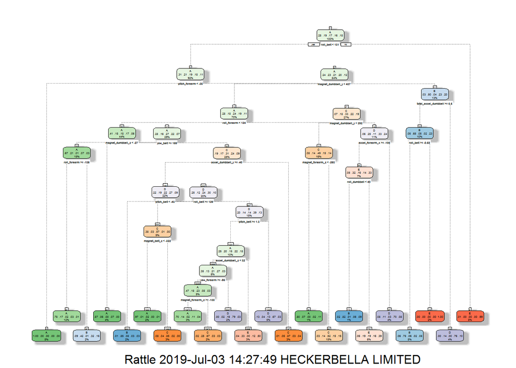

```r
set.seed(1200)
modFitDecTree <- rpart(classe ~ ., data=Training, method="class")
fancyRpartPlot(modFitDecTree)
```

```r
predictDecTree <- predict(modFitDecTree, newdata=Testing, type="class")
confMatDecTree <- confusionMatrix(predictDecTree, Testing$classe)
confMatDecTree
```

```
## Confusion Matrix and Statistics
##
##           Reference
## Prediction    A    B    C    D    E
##          A 1981  242   19   64   27
##          B   78  773   65   97  101
##          C   70  207 1104  195  189
##          D   75  112   94  813   74
##          E   28  184   86  117 1051
##
## Overall Statistics
##
##                Accuracy : 0.7293
##                  95% CI : (0.7193, 0.7391)
##     No Information Rate : 0.2845
##     P-Value [Acc > NIR] : < 2.2e-16
##
##                   Kappa : 0.6573
##
##  Mcnemar's Test P-Value : < 2.2e-16
##
## Statistics by Class:
##
##                      Class: A Class: B Class: C Class: D Class: E
## Sensitivity            0.8875  0.50922   0.8070   0.6322   0.7288
## Specificity            0.9373  0.94611   0.8980   0.9459   0.9352
## Pos Pred Value         0.8491  0.69390   0.6255   0.6961   0.7169
## Neg Pred Value         0.9545  0.88933   0.9566   0.9292   0.9387
## Prevalence             0.2845  0.19347   0.1744   0.1639   0.1838
## Detection Rate         0.2525  0.09852   0.1407   0.1036   0.1340
## Detection Prevalence   0.2973  0.14198   0.2250   0.1489   0.1868
## Balanced Accuracy      0.9124  0.72767   0.8525   0.7890   0.8320
```

## 3. Generalized Boosted Model

```r
set.seed(1200)
controlGBM <- trainControl(method = "repeatedcv", number = 5, repeats = 1)
modFitGBM  <- train(classe ~ ., data=Training, method = "gbm",
                    trControl = controlGBM, verbose = FALSE)
modFitGBM$finalModel
```

```
## A gradient boosted model with multinomial loss function.
## 150 iterations were performed.
## There were 52 predictors of which 52 had non-zero influence.
```

```r
predictGBM <- predict(modFitGBM, newdata=Testing)
confMatGBM <- confusionMatrix(predictGBM, Testing$classe)
confMatGBM
```

```
## Confusion Matrix and Statistics
##
##           Reference
## Prediction    A    B    C    D    E
##          A 2195   63    0    0    4
##          B   20 1414   46    3   21
##          C    7   39 1307   52   17
##          D   10    1   12 1219   15
##          E    0    1    3   12 1385
##
## Overall Statistics
##
##                Accuracy : 0.9585
##                  95% CI : (0.9538, 0.9628)
##     No Information Rate : 0.2845
##     P-Value [Acc > NIR] : < 2.2e-16
##
##                   Kappa : 0.9474
##
##  Mcnemar's Test P-Value : < 2.2e-16
##
## Statistics by Class:
##
##                      Class: A Class: B Class: C Class: D Class: E
## Sensitivity            0.9834   0.9315   0.9554   0.9479   0.9605
## Specificity            0.9881   0.9858   0.9822   0.9942   0.9975
## Pos Pred Value         0.9704   0.9402   0.9191   0.9698   0.9886
## Neg Pred Value         0.9934   0.9836   0.9905   0.9898   0.9912
## Prevalence             0.2845   0.1935   0.1744   0.1639   0.1838
## Detection Rate         0.2798   0.1802   0.1666   0.1554   0.1765
## Detection Prevalence   0.2883   0.1917   0.1812   0.1602   0.1786
## Balanced Accuracy      0.9857   0.9586   0.9688   0.9711   0.9790
```

## Validation of Test data

```r
ValResult <- predict(modRF1, newdata=testing)
ValResult
```

```
##  [1] B A B A A E D B A A B C B A E E A B B B
## Levels: A B C D E
```